# LBB p4ds

Muhammad Nadhif Naufal

2023-06-11

# 1 Explanation

Data yang di gunakana merupakan data telemarketing dari sebuah bank di Portugal. data digunakan supaya kita dapat memprediksi calon nasabah mana yang akan membeli product ketika di dihubungin oleh pihak bank.

# 2 Data Preparation

Pada bagian ini data akan dipersiapkan, agar lebih mudah di analisis

## 2.1 Creating Initial Dataframe

## 2.2 Summary Data Client Bank

> Ini adalah kolom - kolom yang ada di data bank portugal
- Input variables: # bank client data:
- 1 age (numeric)
- 2 job : type of job
- 3 marital : marital status
- 4 education : education
- 5 default: has credit in default?
- 6 balance: average yearly balance, in euros
- 7 housing: has housing loan?
- 8 loan: has personal loan?
- related with the last contact of the current campaign:
- 9 contact: contact communication type
- 10 day: last contact day of the month
- 11 month: last contact month of year
- 12 duration: last contact duration, in seconds
- other attributes:
- 13 campaign: number of contacts performed during this campaign and for this client
- 14 pdays: number of days that passed by after the client was last contacted from a previous campaign
- 15 previous: number of contacts performed before this campaign and for this client
- 16 poutcome: outcome of the previous marketing campaign
- Output variable (desired target):
- 17 y has the client subscribed a term deposit?

```
#> 'data.frame':    45211 obs. of  17 variables:
#>  $ age      : int  58 44 33 47 33 35 28 42 58 43 ...
#>  $ job      : Factor w/ 12 levels "admin.","blue-collar",..: 5 10 3 2 12 5 5 3 6 10 ...
#>  $ marital  : Factor w/ 3 levels "divorced","married",..: 2 3 2 2 3 2 3 1 2 3 ...
#>  $ education: Factor w/ 4 levels "primary","secondary",..: 3 2 2 4 4 3 3 3 1 2 ...
#>  $ default  : Factor w/ 2 levels "no","yes": 1 1 1 1 1 1 1 2 1 1 ...
#>  $ balance  : int  2143 29 2 1506 1 231 447 2 121 593 ...
#>  $ housing  : Factor w/ 2 levels "no","yes": 2 2 2 2 1 2 2 2 2 2 ...
#>  $ loan     : Factor w/ 2 levels "no","yes": 1 1 2 1 1 1 2 1 1 1 ...
#>  $ contact  : Factor w/ 3 levels "cellular","telephone",..: 3 3 3 3 3 3 3 3 3 3 ...
#>  $ day      : int  5 5 5 5 5 5 5 5 5 5 ...
#>  $ month    : Factor w/ 12 levels "apr","aug","dec",..: 9 9 9 9 9 9 9 9 9 9 ...
#>  $ duration : int  261 151 76 92 198 139 217 380 50 55 ...
#>  $ campaign : int  1 1 1 1 1 1 1 1 1 1 ...
#>  $ pdays    : int  -1 -1 -1 -1 -1 -1 -1 -1 -1 -1 ...
#>  $ previous : int  0 0 0 0 0 0 0 0 0 0 ...
#>  $ poutcome : Factor w/ 4 levels "failure","other",..: 4 4 4 4 4 4 4 4 4 4 ...
#>  $ y        : Factor w/ 2 levels "no","yes": 1 1 1 1 1 1 1 1 1 1 ...
```

```r
head(bank)
```

```
#>   age          job marital education default balance housing loan contact day
#> 1  58   management married  tertiary      no    2143     yes   no unknown   5
#> 2  44   technician  single secondary      no      29     yes   no unknown   5
#> 3  33 entrepreneur married secondary      no       2     yes  yes unknown   5
#> 4  47  blue-collar married   unknown      no    1506     yes   no unknown   5
#> 5  33      unknown  single   unknown      no       1      no   no unknown   5
#> 6  35   management married  tertiary      no     231     yes   no unknown   5
#>   month duration campaign pdays previous poutcome  y
#> 1   may      261        1    -1        0  unknown no
#> 2   may      151        1    -1        0  unknown no
#> 3   may       76        1    -1        0  unknown no
#> 4   may       92        1    -1        0  unknown no
#> 5   may      198        1    -1        0  unknown no
#> 6   may      139        1    -1        0  unknown no
```

## 2.3 Missing Value and Duplicates

> step ini akan di cek apakah ada nilai null di semua kolom dari dataframe

```r
colSums(is.na(bank))
```

```
#>       age       job   marital education   default   balance   housing      loan
#>         0         0         0         0         0         0         0         0
#>   contact       day     month  duration  campaign     pdays  previous  poutcome
#>         0         0         0         0         0         0         0         0
#>         y
#>         0
```

```r
anyNA(bank)
```

```
#> [1] FALSE
```

- pada bagian ini kolom ke 14(“pdays”) akan dibuang karana tidak dibutuhkan

```r
Bank <- bank[-14]
```

# 3 Data Explanation

> Ini adalah summary singkat dari dataframe

```
#>       age                 job           marital          education
#>  Min.   :18.00   blue-collar:9732   divorced: 5207   primary  : 6851
#>  1st Qu.:33.00   management :9458   married :27214   secondary:23202
#>  Median :39.00   technician :7597   single  :12790   tertiary :13301
#>  Mean   :40.94   admin.     :5171                    unknown  : 1857
#>  3rd Qu.:48.00   services   :4154
#>  Max.   :95.00   retired    :2264
#>                  (Other)    :6835
#>  default        balance       housing      loan            contact
#>  no :44396   Min.   : -8019   no :20081   no :37967   cellular :29285
#>  yes:  815   1st Qu.:    72   yes:25130   yes: 7244   telephone: 2906
#>              Median :   448                           unknown  :13020
#>              Mean   :  1362
#>              3rd Qu.:  1428
#>              Max.   :102127
#>
#>       day            month          duration         campaign
#>  Min.   : 1.00   may    :13766   Min.   :   0.0   Min.   : 1.000
#>  1st Qu.: 8.00   jul    : 6895   1st Qu.: 103.0   1st Qu.: 1.000
#>  Median :16.00   aug    : 6247   Median : 180.0   Median : 2.000
#>  Mean   :15.81   jun    : 5341   Mean   : 258.2   Mean   : 2.764
#>  3rd Qu.:21.00   nov    : 3970   3rd Qu.: 319.0   3rd Qu.: 3.000
#>  Max.   :31.00   apr    : 2932   Max.   :4918.0   Max.   :63.000
#>                  (Other): 6060
#>     previous           poutcome       y
#>  Min.   :  0.0000   failure: 4901   no :39922
#>  1st Qu.:  0.0000   other  : 1840   yes: 5289
#>  Median :  0.0000   success: 1511
#>  Mean   :  0.5803   unknown:36959
#>  3rd Qu.:  0.0000
#>  Max.   :275.0000
#>
```

> Pada bagian ini akan di pisahkan antara client yang membeli product bank(yes) dan yang tidak membeli(no)

```r
Bankyes <-  Bank[Bank$y == "yes",]
Bankno <-  Bank[Bank$y != "yes",]
```

```r
Bankyes$y <- droplevels(Bankyes$y)
```

```r
Bankno$y <- droplevels(Bankno$y)
```

> Pada bagian ini menapilkan analisis antara client yang membeli product bank dengan jenis pekerjaan client tersebut

```r
table(Bankyes$y, Bankyes$job)
```

```
#>
#>       admin. blue-collar entrepreneur housemaid management retired
#>   yes    631         708          123       109       1301     516
#>
#>       self-employed services student technician unemployed unknown
#>   yes           187      369     269        840        202      34
```

> Dari data diatas kita bisa melihat 5 ter-atas jenis pekerjaan client yang membeli product bank - management (1301) - technician (840) - blue-collar (708) - admin (631) - retired (516)

> Pada bagian ini menapilkan analisis antara client yang membeli product bank dengan tingkat pendidikan client tersebut

```r
table(Bankyes$y, Bankyes$education)
```

```
#>
#>       primary secondary tertiary unknown
#>   yes     591      2450     1996     252
```

> Dari data diatas kita bisa melihat 2 ter-atas tingkat pendidikan client yang membeli product bank - secondary (2450) - tertiary (1996)

> Pada bagian ini menapilkan analisis antara client yang membeli product bank dengan cara client tersebut dihubungi pihak bank

```r
table(Bankyes$y, Bankyes$contact)
```

```
#>
#>       cellular telephone unknown
#>   yes     4369       390     530
```

> Dari data diatas kita bisa melihat data ter-atas cara client tersebut dihubungi pihak bank - cellular (4369)

> Pada bagian ini menapilkan analisis antara client yang membeli product bank dengan tingkat usia client tersebut

```r
table(Bankyes$y, Bankyes$age)
```

```
#>
#>        18  19  20  21  22  23  24  25  26  27  28  29  30  31  32  33  34  35
#>   yes   7  11  15  22  40  44  68 113 134 141 162 171 217 206 221 210 198 209
#>
#>        36  37  38  39  40  41  42  43  44  45  46  47  48  49  50  51  52  53
#>   yes 195 170 144 143 116 120 111 103  93 106 118 113  82 101  72  77  85  85
#>
#>        54  55  56  57  58  59  60  61  62  63  64  65  66  67  68  69  70  71
#>   yes  84  76  68  78  72  88  98  57  39  30  35  21  24  23  21  17  17  25
#>
#>        72  73  74  75  76  77  78  79  80  81  82  83  84  85  86  87  90  92
#>   yes  24  24  13  15  16  22  14  10  12   6   8   6   5   4   4   3   2   2
#>
#>        93  95
#>   yes   2   1
```

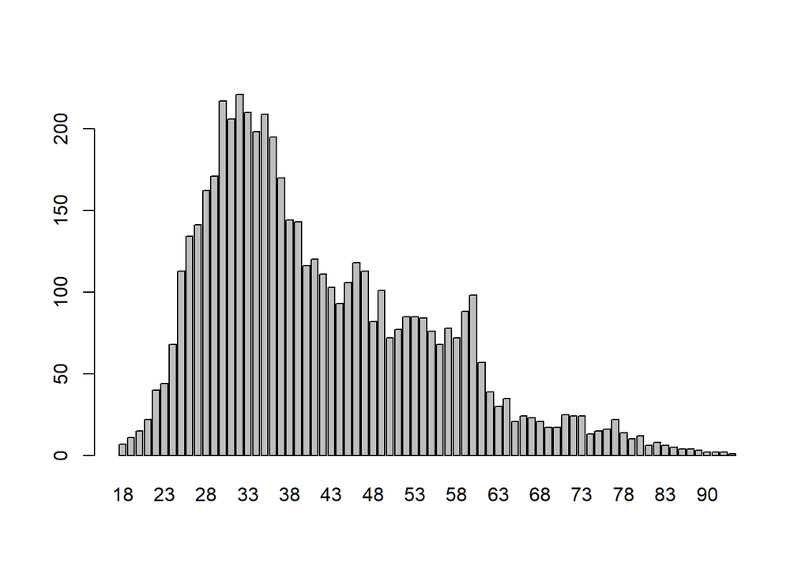

> Dari data diatas kita bisa melihat tingkat usia client yang membeli product bank paling banyak ada diantara *usia 25-43*

# 4 Data Manipulation & Transformation

```r
Bankyes$y <- sapply(Bankyes$y, switch,
       "yes" = 1)
```

```r
str(Bankyes)
```

```
#> 'data.frame':    5289 obs. of  16 variables:
#>  $ age      : int  59 56 41 55 54 42 56 60 39 37 ...
#>  $ job      : Factor w/ 12 levels "admin.","blue-collar",..: 1 1 10 8 1 5 5 6 10 10 ...
#>  $ marital  : Factor w/ 3 levels "divorced","married",..: 2 2 2 2 2 3 2 1 3 2 ...
#>  $ education: Factor w/ 4 levels "primary","secondary",..: 2 2 2 2 3 3 3 2 4 2 ...
#>  $ default  : Factor w/ 2 levels "no","yes": 1 1 1 1 1 1 1 1 1 1 ...
#>  $ balance  : int  2343 45 1270 2476 184 0 830 545 45248 1 ...
#>  $ housing  : Factor w/ 2 levels "no","yes": 2 1 2 2 1 2 2 2 2 2 ...
#>  $ loan     : Factor w/ 2 levels "no","yes": 1 1 1 1 1 2 2 1 1 1 ...
#>  $ contact  : Factor w/ 3 levels "cellular","telephone",..: 3 3 3 3 3 3 3 3 3 3 ...
#>  $ day      : int  5 5 5 5 5 5 6 6 6 6 ...
#>  $ month    : Factor w/ 12 levels "apr","aug","dec",..: 9 9 9 9 9 9 9 9 9 9 ...
#>  $ duration : int  1042 1467 1389 579 673 562 1201 1030 1623 608 ...
#>  $ campaign : int  1 1 1 1 2 2 1 1 1 1 ...
#>  $ previous : int  0 0 0 0 0 0 0 0 0 0 ...
#>  $ poutcome : Factor w/ 4 levels "failure","other",..: 4 4 4 4 4 4 4 4 4 4 ...
#>  $ y        : num  1 1 1 1 1 1 1 1 1 1 ...
```

```r
jobcontact <- aggregate(x = y ~ job+contact, data = Bankyes, FUN= sum)

jobcontact <- jobcontact[jobcontact$contact %in% c("cellular","telephone"),]

jobcontact$contact <- droplevels(jobcontact$contact)

# jobcontact <- jobcontact[jobcontact$contact == "cellular" ,order(jobcontact$y, decreasing = T),]
```

```r
xtabs(y~job+contact,jobcontact)
```

```
#>                contact
#> job             cellular telephone
#>   admin.             529        41
#>   blue-collar        514        38
#>   entrepreneur        89        16
#>   housemaid           84        14
#>   management        1154        60
#>   retired            366       129
#>   self-employed      153        12
#>   services           303        16
#>   student            246        19
#>   technician         731        27
#>   unemployed         173        13
#>   unknown             27         5
```

```r
educationcontact <- aggregate(x = y ~ education+contact, data = Bankyes, FUN= sum)

educationcontact <- educationcontact[educationcontact$contact %in% c("cellular","telephone"),]

educationcontact$contact <- droplevels(educationcontact$contact)
```

```r
xtabs(y~education+contact,educationcontact)
```

```
#>            contact
#> education   cellular telephone
#>   primary        415        91
#>   secondary     2002       158
#>   tertiary      1760       102
#>   unknown        192        39
```

```r
maritalcontact <- aggregate(x = y ~ marital+contact, data = Bankyes, FUN= sum)

maritalcontact <- maritalcontact[maritalcontact$contact %in% c("cellular","telephone"),]

maritalcontact$contact <- droplevels(maritalcontact$contact)
```

```r
xtabs(y~marital+contact,maritalcontact)
```

```
#>           contact
#> marital    cellular telephone
#>   divorced      486        50
#>   married      2230       259
#>   single       1653        81
```

# 5 Business Recomendation

Berdasarkan data yang di gunakan untuk mepromosikan sebuah produk dari sebuah bank di Portugal. dapat ditentukan calon nasabah mana yang ada kemungkinan untuk membeli product ketika di dihubungin oleh pihak bank.

> Recomendations :
- 1. Berdasarkan analisis data contact melalui *cellular* punya kemungkinan besar untuk menerima produk dari bank. Untuk menambah nasabah yang menerima produk dari bank sebaiknya telemarketing lebih berfokus menggunakan contact melalui *cellular*.
- 2. Berdasarkan analisis data dari jenis pekerjaan, nasabah dengan perkerjaan di *management(1301)* paling banyak menerima produk dari bank, dan urutan ke-2 dan ke-3 ada jenis pekerjaan *technician(840)* dan *blue-collar(708)*. Untuk menambah nasabah yang menerima produk dari bank sebaiknya telemarketing berfokus untuk mencari nasabah dengan pekerjaan di *management*, dan juga mencoba menghubungi nasabah yang jenis pekerjaannya *technician* & *blue-collar* dengan target untuk menyamai dengan jumlah nasabah yang menerima produk di jenis pekerjaan *management*